# Exercise lesson 8

Maarten van Doornik

19 januari 2017

## Plot the relationship between Landsat bands and VCF tree cover

These plots show the correlation between the landsat bands and the VCF tree cover:

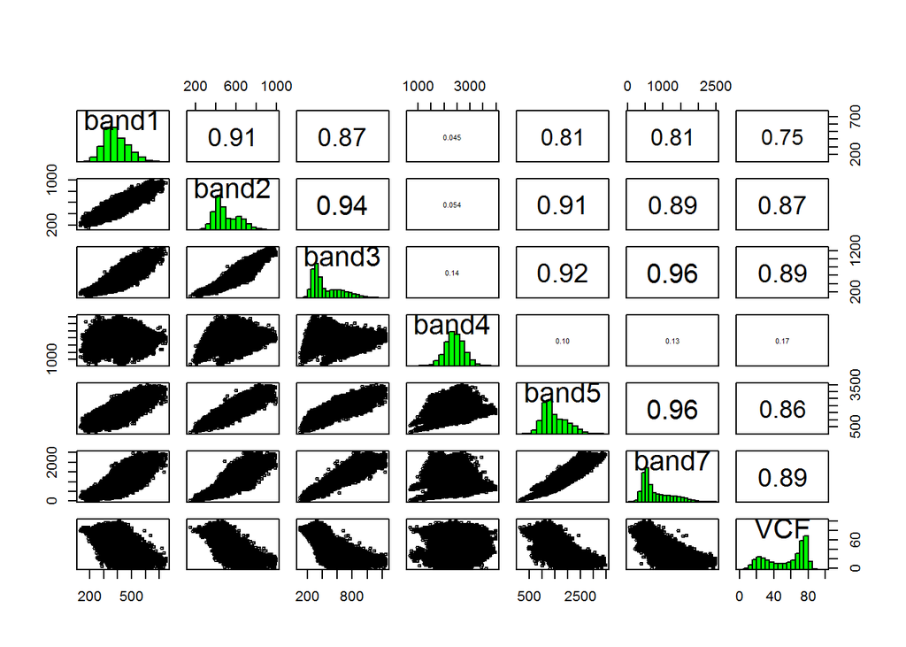

The plots show us that especially band 4 has a low correlation with the other bands and with the VCF tree cover. The other bands seem to be highly correlated.

## Linear model

Next, a linear model was generated to predict the VCF tree cover from the different landsat band. Below is a summary of this linear model:

```r
summary(linmod)
```

```
##
## Call:
## lm(formula = VCF ~ band1 + band2 + band3 + band4 + band5 + band7,
##     data = df)
##
## Residuals:
##     Min      1Q  Median      3Q     Max
## -57.787  -4.605   0.708   5.190  46.932
##
## Coefficients:
##               Estimate Std. Error t value Pr(>|t|)
## (Intercept)  8.634e+01  5.723e-02 1508.75   <2e-16 ***
## band1        9.274e-02  1.879e-04  493.59   <2e-16 ***
## band2       -1.508e-01  2.345e-04 -643.32   <2e-16 ***
## band3       -3.612e-03  1.751e-04  -20.63   <2e-16 ***
## band4        1.614e-02  2.836e-05  568.95   <2e-16 ***
## band5       -1.874e-02  7.447e-05 -251.60   <2e-16 ***
## band7       -1.207e-03  9.887e-05  -12.21   <2e-16 ***
## ---
## Signif. codes:  0 '***' 0.001 '**' 0.01 '*' 0.05 '.' 0.1 ' ' 1
##
## Residual standard error: 8.53 on 1806348 degrees of freedom
##   (15641 observations deleted due to missingness)
## Multiple R-squared:  0.8604, Adjusted R-squared:  0.8604
## F-statistic: 1.856e+06 on 6 and 1806348 DF,  p-value: < 2.2e-16
```

## Pedicted vs observed VCF tree cover

With this linear model, the VCF tree cover was predicted for the whole area and compared tot the observed tree cover. Below is a plot of the comparison of both maps:

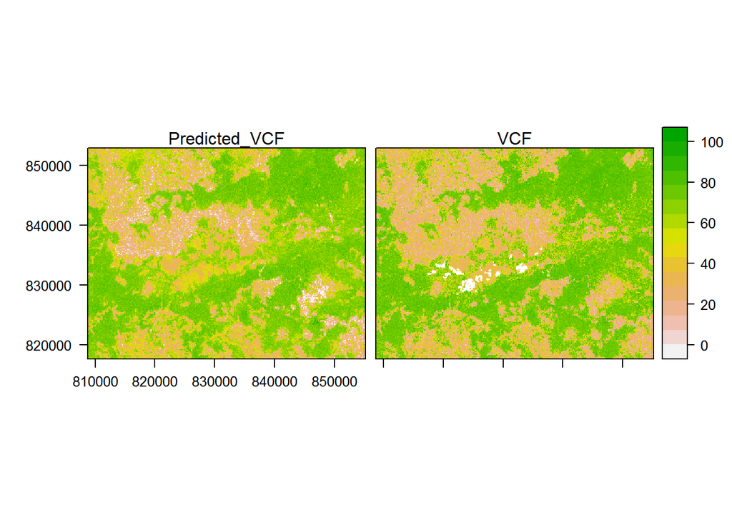

This map shows the difference between the two maps:

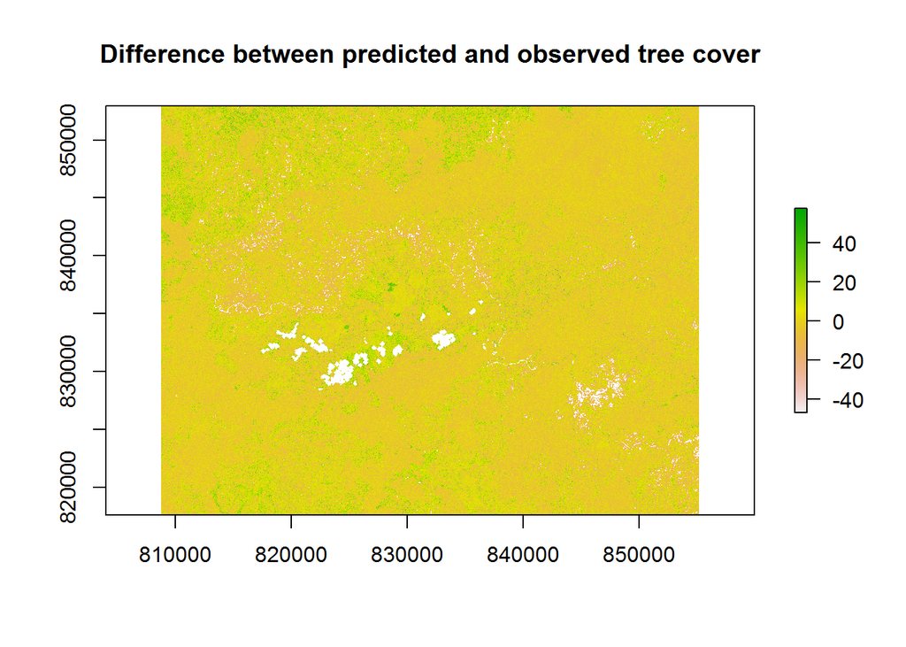

## RMSE

Then the Root mean Squared Error (RMSE) was calculated for the predicted VCF tree cover:

```r
print(rmse)
```

```
## [1] 8.334287
```

## RMSE for different land cover classes

Finally the RMSE was calculated for the different land cover classes cropland, forest and wetland.

```
##   zone      mean      rmse    class
## 1    1  79.84668  8.935697 cropland
## 2    2  24.45892  4.945596   forest
## 3    3 137.34985 11.719635  wetland
```

From this it can be concluded that the error is different for different land cover classes. Forest shows a substantially lower error than wetland and cropland is in between.